# Procesado de Señales e Imágenes Médicas

Ingeniería Biomédica

Ph.D. Pablo Eduardo Caicedo Rodríguez

2026-09-11

## Pregunta guía

¿Por qué la transformada de Fourier no siempre basta para analizar señales biomédicas como un electrocardiograma, una señal mioeléctrica o una señal electroencefalográfica?

Muchas señales biomédicas **no son estacionarias**. Sus componentes cambian con el tiempo, aparecen eventos breves, se superponen artefactos y el instante en que ocurre cada fenómeno sí importa.

## Resultados de aprendizaje

Al finalizar esta clase, el estudiante deberá ser capaz de:

- explicar por qué una representación tiempo-escala puede ser más útil que una representación puramente en frecuencia;
- interpretar de manera básica una descomposición wavelet discreta;
- relacionar niveles de descomposición con componentes de una señal biomédica.

## El problema de Fourier

```
(0.0, 80.0)
```

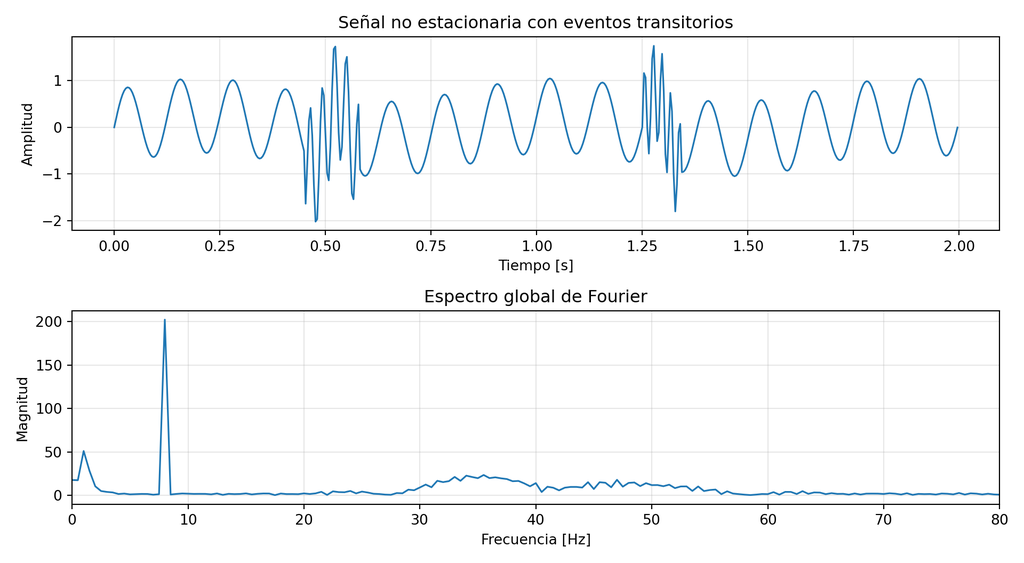

El espectro global informa **qué frecuencias existen**, pero no indica **cuándo ocurren** los eventos transitorios.

## Idea central de una wavelet

Una wavelet es una función oscilatoria y localizada que puede:

- comprimirse para detectar cambios rápidos;
- estirarse para examinar estructuras lentas;
- desplazarse para analizar regiones específicas de la señal.

## Escala y traslación

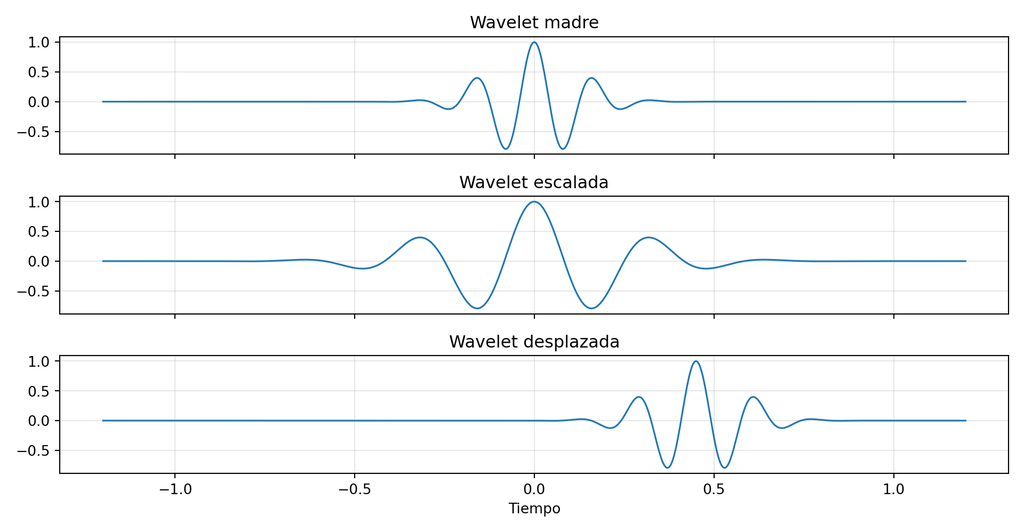

## Propiedades mínimas

Una wavelet útil debe satisfacer ideas como las siguientes:

$$\int_{-\infty}^{\infty}\psi(t)\,dt = 0$$

$$\int_{-\infty}^{\infty} |\psi(t)|^2\,dt < \infty$$

Esto favorece la detección de cambios y garantiza energía finita.

## Transformada wavelet continua

$$W_x(a,b)=\int_{-\infty}^{\infty} x(t)\,\frac{1}{\sqrt{|a|}}\,
\psi^*\!\left(\frac{t-b}{a}\right)\,dt$$

donde:

- $a$ controla la escala;
- $b$ controla la posición temporal.

Escalas pequeñas enfatizan detalles rápidos. Escalas grandes describen tendencias más lentas.

## Representación tiempo-escala

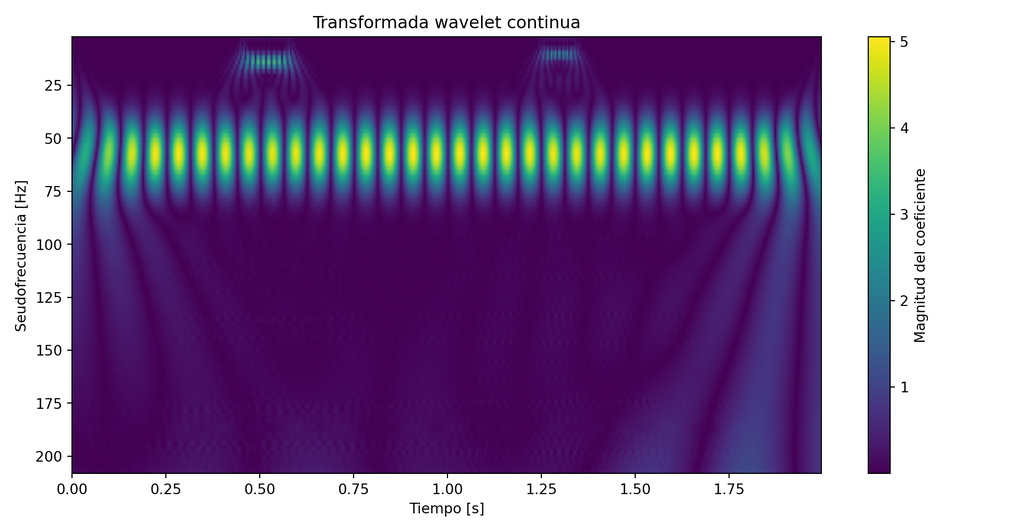

Ahora sí es posible ver **qué ocurre** y **cuándo ocurre**.

## Transformada wavelet discreta

La transformada wavelet discreta usa escalas diádicas y traslaciones discretas.

$$c_{j,k} = \int x(t)\,\psi_{j,k}^*(t)\,dt,
\qquad
\psi_{j,k}(t)=2^{j/2}\psi(2^j t-k)$$

Produce dos familias de coeficientes:

- **aproximaciones**, asociadas a estructura lenta;
- **detalles**, asociados a cambios rápidos.

## Primera lectura intuitiva de la fórmula

La expresión anterior puede leerse así:

- tomo una wavelet;
- la comprimo o la estiro;
- la desplazo sobre la señal;
- calculo qué tan parecidas son localmente.

Por tanto, $W_x(a,b)$ mide:

> **cuánta semejanza hay entre la señal y una wavelet de cierta escala en cierta posición temporal**.

## La wavelet madre, una wavelet escalada y una desplazada

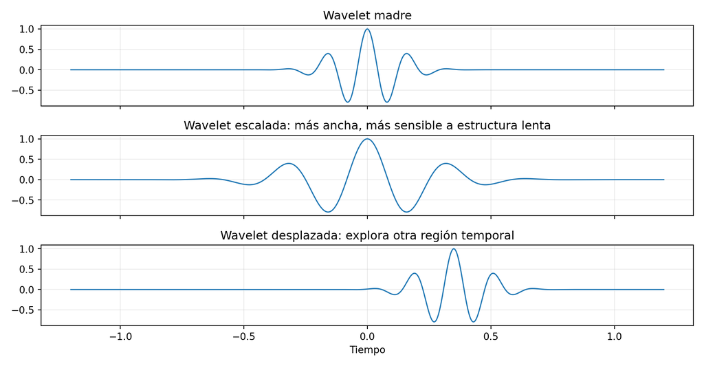

## Qué significa la escala

Si la wavelet es **pequeña**:

- responde mejor a cambios rápidos;
- detecta detalles finos;
- localiza transitorios breves.

Si la wavelet es **grande**:

- integra más contexto temporal;
- responde a variaciones lentas;
- describe estructura global.

## Qué significa la traslación

La traslación $b$ responde a una pregunta simple:

> ¿en qué parte del tiempo estoy mirando la señal?

Por tanto, la transformada wavelet no solo dice **qué tipo de estructura existe**, sino también **dónde aparece**.

## Lectura geométrica: un producto interno

La transformada wavelet puede interpretarse como un producto interno:

$$W_x(a,b)=\langle x(t), \psi_{a,b}(t)\rangle$$

Eso significa que cada coeficiente wavelet es una **proyección** de la señal sobre una función base localizada.

Esta idea es decisiva, porque el análisis multirresolución también se basa en proyecciones, pero organizadas por niveles de resolución.

## De la definición a una intuición operativa

Si proyectamos la señal sobre:

- wavelets grandes, obtenemos una lectura **gruesa**;
- wavelets pequeñas, obtenemos una lectura **fina**.

Entonces ya aparece la intuición central:

> una señal puede describirse en varios niveles de detalle.

Ese es el punto de entrada al análisis multirresolución.

## Una misma señal vista a diferentes escalas

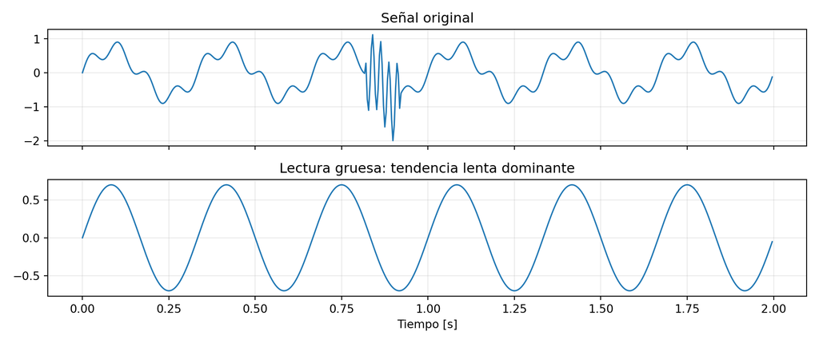

## Idea clave

Cuando observamos a escala gruesa, no desaparece la señal:

- se conserva su estructura general;
- se pierden detalles rápidos;
- se obtiene una representación más compacta.

Cuando observamos a escala fina:

- emergen cambios locales;
- aparecen discontinuidades o transitorios;
- la señal se vuelve más descriptiva, pero menos resumida.

## Definición intuitiva de análisis multirresolución

El análisis multirresolución consiste en representar la señal como suma de dos partes:

- una parte **aproximada**, que contiene la estructura gruesa;
- una parte de **detalle**, que contiene lo que se pierde al pasar a una resolución más gruesa.

En símbolo:

$$\text{señal} = \text{aproximación} + \text{detalle}$$

## La idea recursiva

La clave no es hacerlo una sola vez.

La clave es repetir el proceso:

1. separo aproximación y detalle;
2. tomo solo la aproximación;
3. vuelvo a dividirla en una nueva aproximación y un nuevo detalle.

Así nace una jerarquía de escalas.

## Ejemplo manual con Haar

Tomemos la señal discreta:

$$x[n]=[4,\ 6,\ 10,\ 12]$$

La agrupamos por pares:

$$(4,6),\qquad(10,12)$$

Sobre cada par respondemos dos preguntas:

- ¿cuál es su valor representativo?
- ¿cuánta diferencia hay dentro del par?

## Primer nivel: aproximación

Usando promedios simples:

$$A_1=
\left[
\frac{4+6}{2},
\frac{10+12}{2}
\right]
=
[5,\ 11]$$

Interpretación:

- $5$ resume el primer bloque;
- $11$ resume el segundo bloque.

## Primer nivel: detalle

Ahora medimos diferencia local:

$$D_1=
\left[
\frac{4-6}{2},
\frac{10-12}{2}
\right]
=
[-1,\ -1]$$

Interpretación:

- el detalle registra cuánto cambia cada bloque internamente;
- la aproximación resume;
- el detalle corrige.

## Segundo nivel

Ahora repetimos el procedimiento sobre la aproximación:

$$A_1=[5,\ 11]$$

Nueva aproximación:

$$A_2=\left[\frac{5+11}{2}\right]=[8]$$

Nuevo detalle:

$$D_2=\left[\frac{5-11}{2}\right]=[-3]$$

## Qué significa la descomposición

La señal original queda descrita por:

$$A_2=[8],\qquad D_2=[-3],\qquad D_1=[-1,-1]$$

Lectura:

- $A_2$: estructura más global;
- $D_2$: diferencia entre bloques grandes;
- $D_1$: diferencia dentro de bloques pequeños.

Eso ya es análisis multirresolución en miniatura.

## Visualización del ejemplo Haar

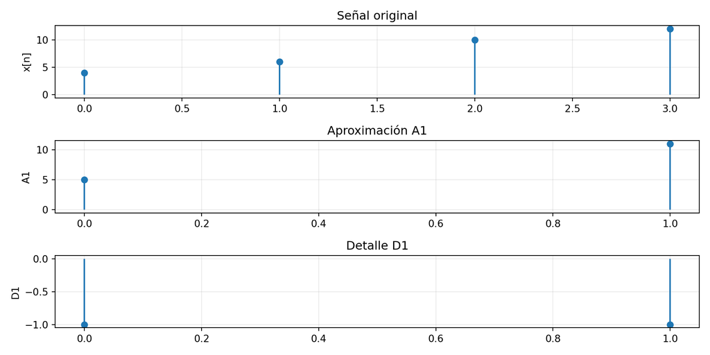

## Qué cambió realmente

No solo cambiamos números.

Cambiamos la **forma de describir la señal**:

- antes: muestras originales;
- ahora: resumen grueso + correcciones por escala.

Ese cambio de representación es la esencia del análisis wavelet discreto.

## Conexión con espacios de resolución

En lenguaje más formal, se habla de espacios:

- $V_j$: espacio de aproximaciones a resolución $j$;
- $W_j$: espacio de detalles que faltan para pasar de $V_{j+1}$ a $V_j$.

La idea clave es:

$$V_j = V_{j+1} \oplus W_{j+1}$$

## Lectura intuitiva de esa relación

La ecuación anterior significa:

- una representación más fina contiene
  - una parte gruesa,
  - más una corrección de detalle.

Es decir:

$$\text{resolución fina}
=
\text{resolución gruesa}
+
\text{detalle perdido}$$

## De la definición integral al algoritmo

La transformada wavelet continua usa todas las escalas y todas las posiciones posibles.

Pero para computación práctica conviene usar:

- escalas discretas;
- traslaciones discretas;
- filtros paso bajo y paso alto.

Así se obtiene el análisis multirresolución implementable.

## Banco de filtros: intuición

En la transformada wavelet discreta:

- el filtro paso bajo produce la **aproximación**;
- el filtro paso alto produce el **detalle**;
- después se submuestrea por 2.

La operación se repite sobre la aproximación.

## Esquema conceptual del proceso

**Entrada**

$$x[n]$$

$$\downarrow$$

**Filtro paso bajo**

$$\rightarrow A_1$$

**Filtro paso alto**

$$\rightarrow D_1$$

Luego:

$$A_1 \rightarrow A_2 + D_2$$

$$A_2 \rightarrow A_3 + D_3$$

y así sucesivamente.

## Resumen de la lógica completa

1. Defino la transformada wavelet como proyección sobre funciones localizadas.
2. Interpreto escala como resolución.
3. Distingo lectura gruesa y lectura fina.
4. Separo la señal en aproximación y detalle.
5. Repito el proceso recursivamente.
6. Obtengo análisis multirresolución.

## Qué debe quedar claro

El análisis multirresolución no es una técnica separada de wavelets.

Es la consecuencia natural de esta idea:

> una señal puede representarse mediante proyecciones organizadas por escala.

## Error conceptual frecuente

No debe pensarse que:

- la aproximación es “lo importante”;
- el detalle es “ruido”.

Eso es falso.

En muchas señales biomédicas:

- el detalle contiene información crítica;
- por ejemplo, transitorios rápidos o complejos QRS.

## Aplicación biomédica inmediata

En electrocardiografía, la intuición sería:

- aproximaciones altas: deriva de línea base y componentes lentas;
- detalles intermedios: complejo QRS;
- detalles finos: ruido rápido o transitorios muy breves.

Por eso el análisis multirresolución es útil en señales biomédicas no estacionarias.

## Síntesis final

La transformada wavelet responde a la pregunta:

> ¿qué patrón aparece, a qué escala y en qué instante?

El análisis multirresolución reorganiza esa respuesta como una jerarquía de:

- aproximaciones;
- detalles;
- niveles sucesivos de resolución.

## Cierre

La idea más importante de la clase es esta:

$$\boxed{
\text{Una señal puede entenderse como suma de estructura gruesa y correcciones de detalle a distintas escalas.}
}$$

## Ejemplo manual con Haar

Para entender la transformada wavelet discreta, conviene empezar con la wavelet de Haar, porque permite ver con claridad la idea de **aproximación** y **detalle**.

Usaremos la señal discreta:

$$x[n] = [4,\ 6,\ 10,\ 12]$$

La lógica será esta:

1. agrupar muestras vecinas;
2. resumir cada par con una aproximación;
3. medir la diferencia dentro de cada par con un detalle;
4. repetir el proceso sobre la aproximación.

## Paso 1: agrupar por pares

Tomamos la señal

$$x[n] = [4,\ 6,\ 10,\ 12]$$

y la dividimos en dos pares:

$$(4,6), \qquad (10,12)$$

La idea de Haar consiste en responder dos preguntas sobre cada par:

$$\text{¿cuál es su valor representativo?}
\qquad
\text{¿qué tan diferentes son sus elementos?}$$

La primera pregunta produce la **aproximación**. La segunda produce el **detalle**.

## Paso 2: versión intuitiva de la aproximación

En una lectura pedagógica inicial, podemos definir la aproximación como el promedio simple de cada par:

$$A_1 = \left[
\frac{4+6}{2},
\frac{10+12}{2}
\right]$$

Por tanto,

$$A_1 = [5,\ 11]$$

Interpretación:

- el par $(4,6)$ queda resumido por $5$;
- el par $(10,12)$ queda resumido por $11$.

La aproximación conserva la estructura gruesa de la señal.

## Paso 3: versión intuitiva del detalle

Ahora calculamos cuánto difieren los elementos dentro de cada par:

$$D_1 = \left[
\frac{4-6}{2},
\frac{10-12}{2}
\right]$$

Entonces,

$$D_1 = [-1,\ -1]$$

Interpretación:

- en el primer par, el valor $4$ está una unidad por debajo del promedio $5$;
- en el segundo par, el valor $10$ está una unidad por debajo del promedio $11$.

El detalle mide variación local.

## Qué significa el primer nivel

Después del primer nivel, la señal ya no se describe con sus cuatro muestras originales, sino con:

$$A_1 = [5,\ 11], \qquad D_1 = [-1,\ -1]$$

Esto quiere decir que la información se reorganizó así:

- $A_1$: comportamiento grueso;
- $D_1$: diferencias rápidas entre muestras vecinas.

La idea central de la transformada wavelet discreta es repetir el procedimiento, pero solo sobre la aproximación.

## Paso 4: segundo nivel sobre la aproximación

Ahora tomamos la aproximación del nivel anterior:

$$A_1 = [5,\ 11]$$

y volvemos a formar un par:

$$(5,11)$$

La nueva aproximación es

$$A_2 = \left[\frac{5+11}{2}\right] = [8]$$

y el nuevo detalle es

$$D_2 = \left[\frac{5-11}{2}\right] = [-3]$$

## Lectura completa de la descomposición

La señal original

$$x[n] = [4,\ 6,\ 10,\ 12]$$

queda representada por:

$$A_2 = [8], \qquad D_2 = [-3], \qquad D_1 = [-1,\ -1]$$

Esta escritura indica tres niveles de información:

- $A_2$: tendencia más global de toda la señal;
- $D_2$: diferencia entre los dos bloques grandes;
- $D_1$: diferencias locales dentro de cada bloque pequeño.

## Reconstrucción intuitiva desde $A_2$, $D_2$ y $D_1$

Primero reconstruimos $A_1$ a partir de $A_2$ y $D_2$:

$$A_1^{(1)} = A_2 + D_2 = 8 + (-3) = 5$$

$$A_1^{(2)} = A_2 - D_2 = 8 - (-3) = 11$$

Por tanto,

$$A_1 = [5,\ 11]$$

Luego reconstruimos la señal original usando $A_1$ y $D_1$:

Para el primer par,

$$x[0] = 5 + (-1) = 4
\qquad
x[1] = 5 - (-1) = 6$$

Para el segundo par,

$$x[2] = 11 + (-1) = 10
\qquad
x[3] = 11 - (-1) = 12$$

Así recuperamos

$$x[n] = [4,\ 6,\ 10,\ 12]$$

## Qué aprendimos con la versión intuitiva

La versión intuitiva muestra tres ideas fundamentales:

- la señal puede resumirse por escalas;
- la aproximación conserva lo grueso;
- el detalle conserva lo cambiante.

Pedagógicamente es útil, pero todavía no es la forma ortonormal estándar usada en teoría wavelet.

## Versión ortonormal de Haar

En la formulación estándar, Haar usa normalización con $\sqrt{2}$.

Para un par $(a,b)$, los coeficientes son:

$$A = \frac{a+b}{\sqrt{2}}
\qquad
D = \frac{a-b}{\sqrt{2}}$$

Aplicando esto a la señal:

$$x[n] = [4,\ 6,\ 10,\ 12]$$

obtenemos en el primer nivel:

$$A_1 =
\left[
\frac{4+6}{\sqrt{2}},
\frac{10+12}{\sqrt{2}}
\right]
=
\left[
\frac{10}{\sqrt{2}},
\frac{22}{\sqrt{2}}
\right]$$

$$D_1 =
\left[
\frac{4-6}{\sqrt{2}},
\frac{10-12}{\sqrt{2}}
\right]
=
\left[
\frac{-2}{\sqrt{2}},
\frac{-2}{\sqrt{2}}
\right]$$

## Segundo nivel ortonormal

Ahora usamos la aproximación del primer nivel:

$$A_1 =
\left[
\frac{10}{\sqrt{2}},
\frac{22}{\sqrt{2}}
\right]$$

La nueva aproximación es

$$A_2 =
\frac{
\frac{10}{\sqrt{2}} + \frac{22}{\sqrt{2}}
}{\sqrt{2}}
=
\frac{32/\sqrt{2}}{\sqrt{2}}
=
16$$

El nuevo detalle es

$$D_2 =
\frac{
\frac{10}{\sqrt{2}} - \frac{22}{\sqrt{2}}
}{\sqrt{2}}
=
\frac{-12/\sqrt{2}}{\sqrt{2}}
=
-6$$

Por tanto, la descomposición ortonormal queda:

$$A_2 = [16], \qquad D_2 = [-6], \qquad D_1 = \left[-\frac{2}{\sqrt{2}},\ -\frac{2}{\sqrt{2}}\right]$$

## Comparación entre ambas lecturas

La versión intuitiva usa promedios y semidiferencias:

$$A = \frac{a+b}{2}, \qquad D = \frac{a-b}{2}$$

La versión ortonormal usa:

$$A = \frac{a+b}{\sqrt{2}}, \qquad D = \frac{a-b}{\sqrt{2}}$$

La diferencia no es conceptual sino de **normalización**.

Para enseñanza inicial, la primera versión facilita la intuición. Para teoría, energía y algoritmos formales, debe usarse la versión ortonormal.

## Interpretación biomédica del ejemplo

En procesamiento de señales biomédicas, este ejemplo enseña la lógica central:

- la aproximación representa tendencias más lentas;
- el detalle representa cambios más rápidos;
- al aumentar el nivel, se observa la señal en escalas más gruesas.

Eso explica por qué la transformada wavelet discreta resulta útil para separar:

- complejos rápidos en electrocardiografía;
- artefactos de alta frecuencia;
- variaciones lentas de línea base;
- transitorios en señales mioeléctricas o electroencefalográficas.

## Pregunta de verificación

Si en una señal biomédica aparece un evento breve y abrupto, como un transitorio rápido, ¿esperas que su energía se concentre principalmente en la aproximación o en los detalles?

La respuesta correcta es: en los **detalles**, porque representan cambios locales y componentes más rápidas.

## Análisis multirresolución

En implementación discreta, la descomposición puede resumirse así:

$$A_{j+1} = (A_j * h)\downarrow 2
\qquad
D_{j+1} = (A_j * g)\downarrow 2$$

donde:

- $h$ es un filtro de aproximación;
- $g$ es un filtro de detalle;
- $\downarrow 2$ representa submuestreo por dos.

## Lectura por bandas aproximadas

Si la frecuencia de muestreo es $f_s$, una guía útil es:

$$D_j \approx \left[\frac{f_s}{2^{j+1}},\ \frac{f_s}{2^j}\right]$$

No es una frontera exacta, pero permite interpretar los niveles.

## Bandas aproximadas para $f_s=360$ Hz

| Componente | Banda aproximada |
| --- | --- |
| $D_1$ | 90 a 180 Hz |
| $D_2$ | 45 a 90 Hz |
| $D_3$ | 22.5 a 45 Hz |
| $D_4$ | 11.25 a 22.5 Hz |
| $D_5$ | 5.625 a 11.25 Hz |
| $A_5$ | 0 a 5.625 Hz |

## Conexión biomédica

En un electrocardiograma aparecen componentes con distinta duración:

- el complejo QRS es breve y abrupto;
- las ondas P y T son más lentas;
- la deriva de línea base es aún más lenta;
- el ruido muscular suele ocupar bandas más rápidas.

La transformada wavelet ayuda a separarlos por escala.

## Electrocardiograma sintético

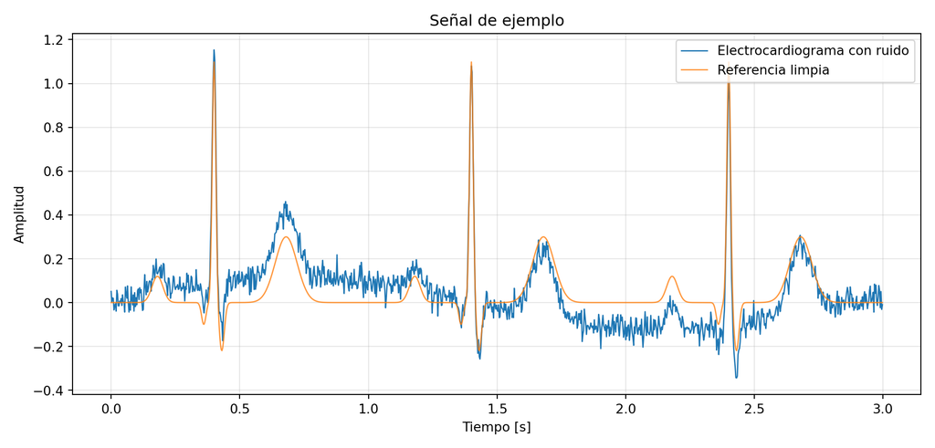

## Descomposición wavelet del electrocardiograma

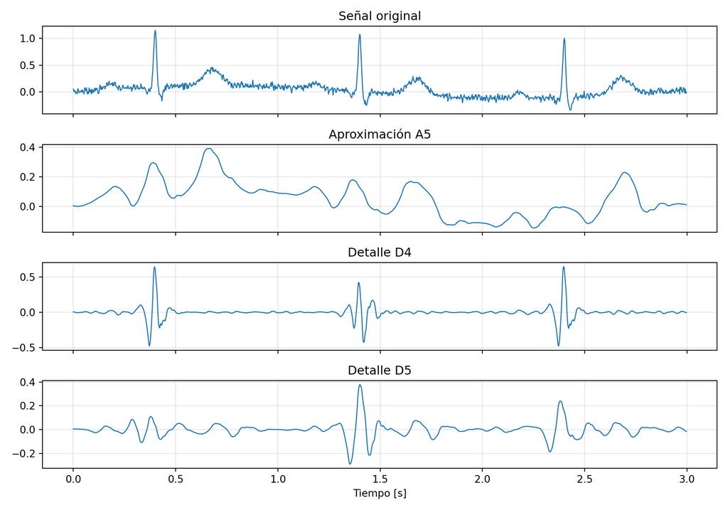

## Interpretación biomédica

| Componente fisiológico o artefacto | Comportamiento esperado | Nivel donde suele observarse mejor |
| --- | --- | --- |
| Complejo QRS | Evento breve y abrupto | $D_3$ a $D_4$ |
| Onda P | Más ancha y de menor energía | $D_4$ a $D_5$ |
| Onda T | Lenta y ancha | $D_5$ o aproximación |
| Deriva de línea base | Muy lenta | Aproximaciones altas |
| Ruido muscular | Rápido e irregular | $D_1$ a $D_2$ |

## Implementación mínima en Python

```python
import pywt

wavelet = "db4"
nivel = 5

coeficientes = pywt.wavedec(ecg_noisy, wavelet, level=nivel)
aproximacion = coeficientes[0]
detalles = coeficientes[1:]

print("Número de conjuntos de coeficientes:", len(coeficientes))
```

```
Número de conjuntos de coeficientes: 6
```

```python
print("Longitud de la aproximación:", len(aproximacion))
```

```
Longitud de la aproximación: 40
```

```python
print("Longitudes de detalles:", [len(d) for d in detalles])
```

```
Longitudes de detalles: [40, 74, 141, 275, 543]
```

## Criterio para elegir la wavelet

No existe una wavelet universalmente mejor.

La elección depende de:

- la frecuencia de muestreo;
- la morfología de la señal;
- el objetivo del análisis;
- el desempeño observado en la tarea concreta.

Para electrocardiografía, `db4` suele usarse con frecuencia, pero debe justificarse con resultados.

## Advertencia metodológica

Cuatro errores frecuentes:

- confundir escala con frecuencia exacta;
- creer que un coeficiente alto implica una conclusión clínica;
- olvidar que la descomposición depende del muestreo;
- usar la herramienta matemática sin interpretación fisiológica.

La transformada wavelet **no reemplaza** el criterio biomédico.

## Verificación conceptual

1. Si una señal contiene un evento muy breve, ¿esperas verlo con mayor claridad en niveles finos o gruesos?
2. Si una señal presenta deriva de línea base, ¿debería aparecer en detalles finos o en aproximaciones altas?
3. ¿Qué ventaja ofrece una representación tiempo-escala frente a un espectro global?

## Síntesis final

La transformada wavelet es útil porque permite analizar señales biomédicas cuyos fenómenos cambian con el tiempo.

La versión continua ofrece una lectura tiempo-escala.

La versión discreta permite descomposición eficiente, filtrado y extracción de características.

En electrocardiografía, el análisis multirresolución ayuda a separar complejos rápidos, ondas lentas y artefactos bajo una interpretación fisiológica cuidadosa.

## Cierre

La pregunta importante no es solamente cómo calcular coeficientes wavelet.

La pregunta importante es esta:

**¿qué componente fisiológico o artefacto estoy representando en cada escala?**